# Can Wage Rigidity Make AI Bad for Workers?

A Sticky-Wage Check in TANK-CW: Productivity Without Wage Adjustment

## The Question

The task-displacement framework (see `displacement_explainer.qmd`) explains how AI can raise output while harming workers through a **structural** channel: automation replaces the set of tasks humans perform, compressing the human marginal product of labor and pulling wages down.

This document tests a simpler, purely nominal version of the same outcome. The question is: **can extreme wage stickiness alone produce a world where AI raises output but workers capture none of the gains — even when the shock is entirely labor-augmenting with no task displacement?**

The only thing that differs between the two scenarios is $\kappa_w$, the slope of the wage Phillips curve. Prices adjust at the same normal speed in both cases.

Prices are kept at normal stickiness ($\kappa \approx 0.117$) in both scenarios. This keeps the Taylor rule’s nominal anchor intact and the model determinate.

## The Model

Standard TANK-CW (Two-Agent New Keynesian with Capital and Wealth), model version 1: workers are $\lambda \approx 0.80$ of the population, hand-to-mouth. Capitalists ($1-\lambda \approx 0.20$) own capital and receive profits.

Standard Cobb-Douglas production — no task allocation block:

$$y^m_t = (1-\alpha)(z_t + n_t) + \alpha(u_t + k_{t-1})$$

$$mpl_t = y^m_t - n_t, \qquad w_t = mc_t + mpl_t$$

Near-permanent productivity shock: $z_t = 0.999\, z_{t-1} + \varepsilon^Z_t$.

### The Wage Phillips Curve Slope as the Scenario Control

$$\pi^w_t = \beta\,\pi^w_{t+1} + \kappa_w\,(mrs_t - w_t), \qquad \pi^w_t = w_t - w_{t-1}$$

From Calvo wage-setting with average spell $s_w$ quarters:

$$\kappa_w = \frac{(1 - \text{calvo}_w)(1 - \beta\,\text{calvo}_w)}{\text{calvo}_w},
\qquad \text{calvo}_w = 1 - \frac{1}{s_w}$$

| Scenario | $s_w$ (quarters) | $\kappa_w$ | $\kappa$ (prices) |
| --- | --- | --- | --- |
| Normal wages | 3.5 | 0.117 | 0.117 (unchanged) |
| Frozen wages | 100 | 0.0002 | 0.117 (unchanged) |

As $\kappa_w \to 0$, the wage Phillips curve flattens: wages are entirely forward-looking and do not respond to the MRS–wage gap within any reasonable horizon. The wage equation becomes $\pi^w_t \approx \beta\,\pi^w_{t+1}$, and since $\pi^w_t = w_t - w_{t-1}$, wages barely move period to period.

Prices still adjust normally in both cases, so the Taylor rule continues to respond to inflation and the model remains determinate.

## Results

*Generate the figure by running `compare_sticky_price.m` in MATLAB/Dynare.*

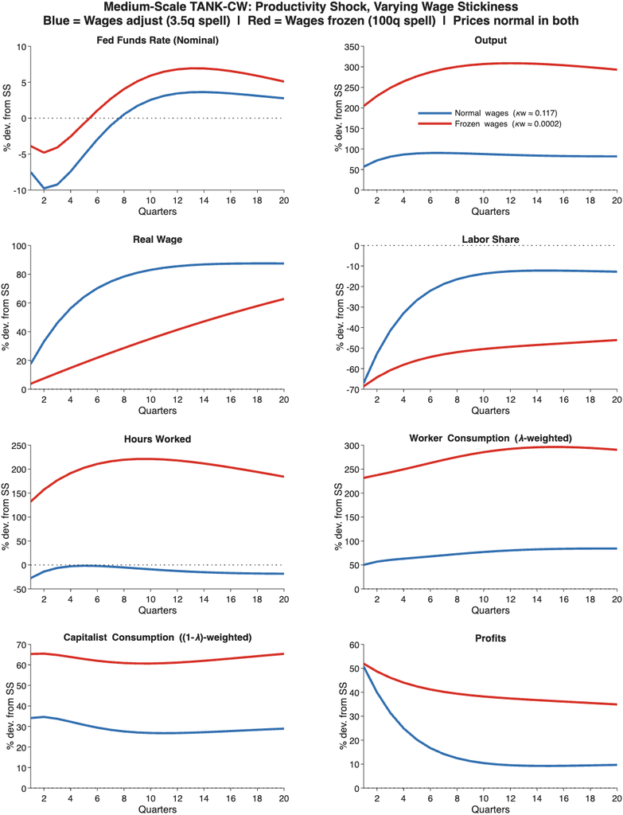

**Figure 1.** Impulse responses to a one-unit near-permanent productivity shock ($\rho_Z = 0.999$). **Blue**: normal wage stickiness ($\kappa_w \approx 0.117$, 3.5-quarter average wage spell). **Red**: frozen wages ($\kappa_w \approx 0.0002$, 100-quarter average spell). Prices adjust at identical normal speed in both scenarios ($\kappa \approx 0.117$). All variables shown as percent deviations from steady state. Horizon: 20 quarters. Model: TANK-CW, no task displacement.

**Panel 1 — Fed Funds Rate (Nominal):** Zero means the nominal interest rate is at its steady-state level — monetary policy is neutral. Both scenarios cut rates: prices adjust normally in both, so the productivity shock still compresses marginal costs, generates some disinflation, and the Taylor rule responds. But the cut is smaller under frozen wages (red). Under normal wages (blue), falling labor costs amplify the deflationary signal; under frozen wages, wages don’t fall and the disinflation comes only from the price channel, producing a weaker rate cut.

**Panel 2 — Output:** Zero means output is at its pre-shock steady-state level. Both lines are well above zero — a productivity gain raises output regardless of wage stickiness. The red line (frozen wages) is dramatically higher: when wages are stuck, firms face very cheap labor relative to the improved productivity level and hire aggressively, expanding hours (see Panel 5), which further raises output. The monetary accommodation is also slightly larger in the blue case over the longer run as wages feed back into prices, but the dominant effect is the hours channel.

**Panel 8 — Profits:** Zero means profits are at steady-state. Both positive. Under frozen wages (red), profits are higher and more persistent: output rises sharply (from both productivity and hours), the wage bill barely moves, and the surplus accrues to firm owners. Under normal wages (blue), profits rise initially but fall back as wages rise and claim the productivity dividend; profits return toward steady state over the 20-quarter window.

## Specific Questions

### Why Does the Fed Cut Less Under Frozen Wages?

The Taylor rule responds to realized price inflation:

$$R_t = \rho_r R_{t-1} + (1-\rho_r)\phi_\pi \pi_t + \ldots$$

In both scenarios, prices adjust normally (kappa = 0.117). The productivity shock lowers marginal cost $mc_t = w_t - mpl_t$. Under normal wages, $w_t$ rises as wages adjust but $mpl_t$ rises more, so $mc_t$ falls substantially → deflation → larger rate cut.

Under frozen wages, $w_t$ barely moves, so $mc_t = w_t - mpl_t \approx -mpl_t$ falls by even more than in the normal case. This actually creates *more* deflation from the cost side. But there is an offsetting force: the large expansion in hours drives output and demand up sharply. Higher demand puts upward pressure on marginal costs through the utilization and capital channels. The net effect on $mc_t$, and therefore on inflation and the rate cut, depends on the balance of these forces. In the model, the demand expansion partially offsets the cost compression, so the inflation signal is somewhat smaller under frozen wages, and the Fed cuts rates by a bit less.

### Why Are Hours So Much Higher Under Frozen Wages?

Hours are determined jointly by labor demand (firms hire until the wage equals the value of the marginal product) and the wage Phillips curve.

Under normal wages, productivity rises, MPL rises, and the wage Phillips curve transmits this into higher wages over a few quarters. As wages rise, the labor cost to firms increases, moderating their desire to hire. The hours expansion is limited. Additionally, higher wages create an income effect on labor supply: workers feel richer and choose to work less.

Under frozen wages, MPL rises but wages don’t. The wedge between MPL and the wage grows continuously as the near-permanent productivity shock accumulates. Firms see labor as extraordinarily cheap relative to what it produces. They hire much more. Workers have no income effect pulling them away from work (their wage per hour hasn’t changed), so they supply whatever hours firms demand. The result is a large, persistent hours boom.

## Comparison to the AR Task Displacement Framework

Both this experiment and the task displacement experiment produce workers who fail to capture productivity gains. The mechanisms and dynamics are different:

[output not shown]

## Blog Post Notes

### The Core Story

This experiment shows that distributional harm from AI does not require structural displacement. Wage rigidity alone — the inability of workers to bargain up their wages in response to higher productivity — is sufficient to reproduce the same inequality outcome.

### Why This Is the Right Simple Test

The AR task displacement model is rich but complex: it requires modeling an automation frontier, a cost-minimizing threshold, and a task-share equilibrium. This experiment strips all of that away. The production function is plain Cobb-Douglas. The only change between scenarios is one number: $\kappa_w$, the speed at which wages respond to labor market conditions. The result is the same distributional pattern. This suggests that the mechanism connecting AI to worker harm may be more about **wage-setting power** than about the specific technology of task replacement.

### Key Policy Takeaways

1. **$\kappa_w$ is a policy variable.** Union density, sector-level wage bargaining, minimum wage indexation, and profit-sharing mandates all affect how quickly wages respond to productivity gains. Policies that raise $\kappa_w$ help workers capture AI gains. A labor market with weak worker bargaining power operates in the low-$\kappa_w$ regime.
2. **More output is not enough.** Under frozen wages, output is dramatically higher than under normal wages. A policymaker watching GDP would see a stronger economy. But worker welfare is lower on a per-hour basis. Hours-adjusted or wage-adjusted measures of worker wellbeing tell a completely different story from headline GDP.
3. **The Fed cannot fix distributional rigidity.** In both scenarios the Fed cuts rates and provides some accommodation. But the rate cut under frozen wages primarily benefits capitalists (through investment and asset prices) rather than workers (who would need higher wages, not lower interest rates, to benefit). Monetary policy is not a substitute for labor market institutions that allow wages to rise with productivity.